# Module7_Group9

Nicole Wei

2023-11-19

## Introduction

The force-length relationship of muscle function is directly related to actin-myosin overlap in sacromere – the limited formation of cross bridges due to attachment range. The maximal isometric force produced is directly related to cross bridges formation.

The human upper limb transect a lever system, though the mechanical advantage (MA) that predicts the amount of output transmitted by the input force generally accords to 0.2 in the system. This indicates that any force applied to the in-level results in 20% of that force at the end of the out-level. However, because the angle changes as the forearm rotates, the output is not entirely predictable by MA alone. According to paper on uncovering the FL relationships of the input muscles (@rassier1999length), physiologists Rassier, Macintosh, and Herzog have found that studying the force produced by a biomechanical system can still be useful. As a result, we underline the assumption that the force we measure at the hand as the muscle produces isometric force at various lengths is a reasonable reflection of the FL relationship in this study.

It has previously been shown in the article by Yeung and Yeung in 2008 that the force/torque-length/angle relationship shifts soon after and long after eccentric fatigue (@yeung2007shift). In this study, we aim to continue investigating th e FL relationship within the human upper limb, particularly honing in on the forearm flexors and their response to eccentric fatigue: 1) Does the isometric maximum voluntary contraction (MVC) force-angle data across the entire class align with a standard FL relationship, both in control and fatigued states? 2) Is there a significant difference in the θmax between the FL relationships of the control and fatigue conditions?

To investigate the effect of eccentric fatigue of elbow flexor muscles, the isometric force over the range of motion of the forearm produced by maximum voluntary contraction (MCV) is measured by a portable Arduino-based force-data acquisition system (DAQ) for 30 seconds at 11 different angles (45-157.25, with 11.25 degrees of increment) and the data is analyzed.

## Methods

### Assembling the DAQ

an 100-kg S-type Load Cell with HX711 amplifier and an Arduino Uno microcontroller are provided by Prof. Kenaley and are wired together by the group.

### Constructing a ganiometer

A small disc is outlined and cut from a piece of cardboard. The circle is separated into equal segments with a protractor from 45-157.25 degrees with a 11.25 degree of increments.

### Using a geniometer

Locate the center of the elbow joint in lateral view and designate this position with a marker. Draw a line along the lateral margin of the radius starting from the marked location. Pierce a hole through the center of the goniometer and attach it to the upper arm in such a way that its center aligns with your mark at the elbow joint, and the 0-180 axis corresponds with the long axis of the humerus.

### Collecting isometric force data from MVCs (setup)

The load-cell is affixed to a wooden or plastic dowel with a zip tie at one end and has a looped zip tie attached to the other. Pass the looped zip tie around the provided C-clamp and fasten the clamp to a table at O’neill library that won’t move under the torque of your forearm. The elbow is supported by the table.

### Collecting control isometric force data from MVCs

start the data collection at the largest arm angle, 157.5. At each angle, flex the elbow as hard as you can to produce a MVC, resetting your DAQ system each time.

### Collecting isometric force data from MVCs after eccesntric fatigue

Each group member performs isokinetic controlled drops of a heavy object weighing 1/3 of maximum isometric force recorded in the control experiments. In this case, each group member performed bicep curls with dominant hand using our own backpack (each contains one laptop and one ipad). Each group member start with the book bag with the hand not participating in the experiment and transfer it to the other hand while fully flexing the forearm (bicep curls). Once the bag is in the hand designated for the experiment, gradually and consistently lower the bag. When the arm is fully extended, grasp the book bag with the free hand and proceed to flex the forearm being studied. Repeat the process by passing the bag back to the study hand. Maintain a continuous repetition of this exercise for a duration of 3 minutes, ensuring the cycles are consistently timed by monitoring the duration, ideally around 3-4 seconds per cycle. Each member is tired at the end of the trial. After each person fatigue their flexors, wait 2 min. Then repeat the experiment exactly as one did for the control data.

## Results

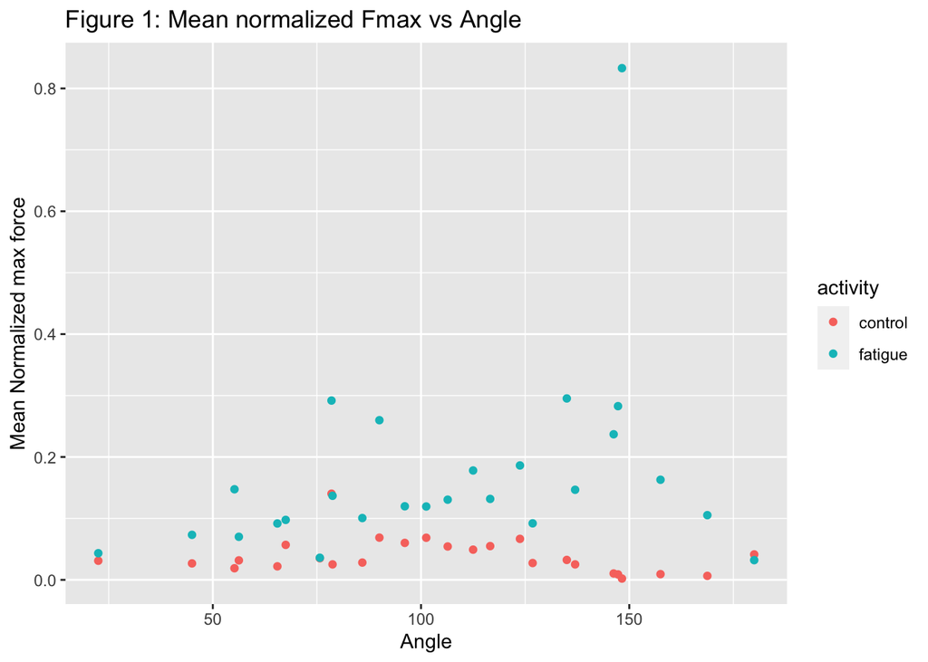

As we could see from this figure, for almost every each angle, the fatigue group’s mean normalized max force is almost always higher than the control group’s, which is interesting. To further answer the question:Is there a significant shift between theta max between the control and fatigue FL relationships? We need to construct polynomial models to estimate the maximum force

```
## Analysis of Variance Table
##
## Response: theta_max
##           Df  Sum Sq Mean Sq F value  Pr(>F)
## activity   1  2796.5 2796.49  5.8026 0.01981 *
## Residuals 49 23614.9  481.94
## ---
## Signif. codes:  0 '***' 0.001 '**' 0.01 '*' 0.05 '.' 0.1 ' ' 1
```

```
##
##
## Table: Table 1: Mean shift in theta max
##
## | mean.shift| se.shift|
## |----------:|--------:|
## |   14.77027| 5.455925|
```

The theta angel change is 14.78 and the anova test has a p-value of 0.01981, which is statistically significant.

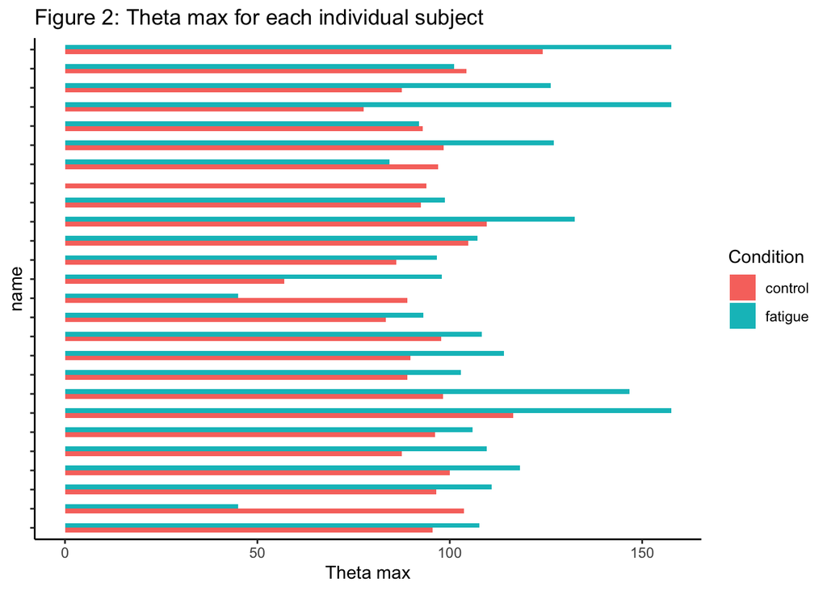

## Discussion

Our project aim to investigate whether force-angle data for isometric MVC accord to a typical FL relationship both under control and fatigued conditions and whether there is a significant shift between theta-max between the control and fatigue FL relationships. In general, our project specifically investigated how fatigue influences the force-length relationship in the upper limbs

After data processing, we found that the angle at which the maximum contraction force is generated for the fatigue group is higher than the control group and we were able to identify approximately 14.7 degrees shifts between the the maximum force-producing angles between control and fatigure groups.

## Author Contribution

Nicole: finish introduction, reference search and methods. Aid Weihang in producing the code for data analysis

Weihang: finish the code for data analysis

Stacey: set up the DAQ and was in charge of data collection and upload.